# Comentário Inicial - Alálise Exploratório

## Informações sobre a Dataset

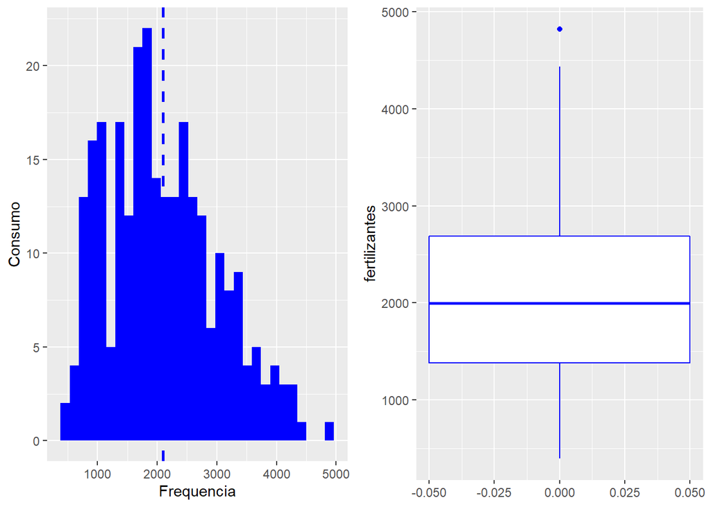

```r
# Informações iniciais sobre o Dataset

b1 <- fertcons %>% ggplot(aes(x=fertilizantes)) +
        geom_histogram(bins=30, fill="blue")+
        xlab("Frequencia")+
        ylab("Consumo")+
        geom_vline(aes(xintercept=mean(fertilizantes)),color="blue", linetype="dashed", size=1)

b2 <- fertcons %>% ggplot(aes(y= fertilizantes)) +
      geom_boxplot(width = .1, color = "blue")

grid.arrange(b1,b2,ncol = 2)
```

```r
any(is.na(fertcons))
```

```
## [1] FALSE
```

```r
pander(summary(fertcons))
```

| fertilizantes |
| --- |
| Min. : 396 |
| 1st Qu.:1381 |
| Median :1997 |
| Mean :2097 |
| 3rd Qu.:2688 |
| Max. :4824 |

Realizando os testes de normalidade verificamos que há divergências entre o teste de Shapiro e o Komolgorov, no primeiro os dados não são considerados normais ( P-Value < 0.05) e no segundo são considerados normais (P-Value > 0.05)

```r
# Shapiro-Wilk

shapiro.test(fertcons$fertilizantes)
```

```
##
##  Shapiro-Wilk normality test
##
## data:  fertcons$fertilizantes
## W = 0.97385, p-value = 7.936e-05
```

```r
# Kolmogorov-Smirnov

ks.test(fertcons$fertilizantes, mean(fertcons$fertilizantes), sd(fertcons$fertilizantes))
```

```
##
##  Two-sample Kolmogorov-Smirnov test
##
## data:  fertcons$fertilizantes and mean(fertcons$fertilizantes)
## D = 0.54104, p-value = 0.9325
## alternative hypothesis: two-sided
```

## Criando e analisando a série temporal

Foi criada uma série temporal chamada ts.fertcons seu gráfico foi plotado e decomposto.

É possível identificar no gráfico uma leve tendência de crescimento pois a série inicia em 1998 com valores em torno de 1.000 e o seu final está em torno de 3.000 indicando que a entrega de fertilizantes tem aumentado ao longo dos anos. Em 2008, provavelmente por conta da crise econômica, observa-se um vale no gráfico que contraria um pouco a tendência.

É possível verificar a existência de sazonalidade, cuja amplitude vai aumentando, com exceção de 2003,2004, 2008 e 2009, parecendo indicar um padrão multiplicativo.

```r
# Criando a TS

ts.fertcons <- ts(fertcons, frequency = 12, start = c(1998,1), end = c(2020,4))
class(ts.fertcons)
```

```
## [1] "ts"
```

```r
# Plot simples da série

frequency(ts.fertcons)
```

```
## [1] 12
```

```r
start(ts.fertcons)
```

```
## [1] 1998    1
```

```r
end(ts.fertcons)
```

```
## [1] 2020    4
```

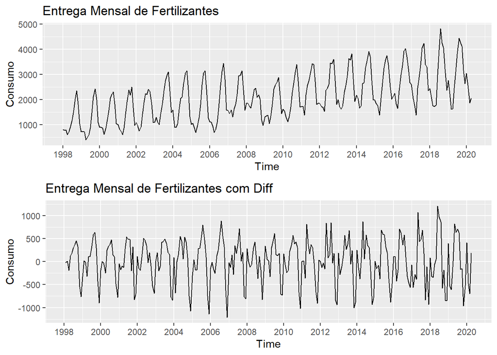

```r
s1 <- autoplot(ts.fertcons, frequency = 12, start=c(1998,1)) +
  ylab("Consumo") +
  scale_x_continuous(breaks = scales::extended_breaks(12))+
  ggtitle("Entrega Mensal de Fertilizantes")
s2 <- autoplot(diff(ts.fertcons), frequency = 12, start=c(1998,1)) +
  ylab("Consumo") +
  scale_x_continuous(breaks = scales::extended_breaks(12))+
  ggtitle("Entrega Mensal de Fertilizantes com Diff")
grid.arrange(s1,s2,nrow = 2)
```

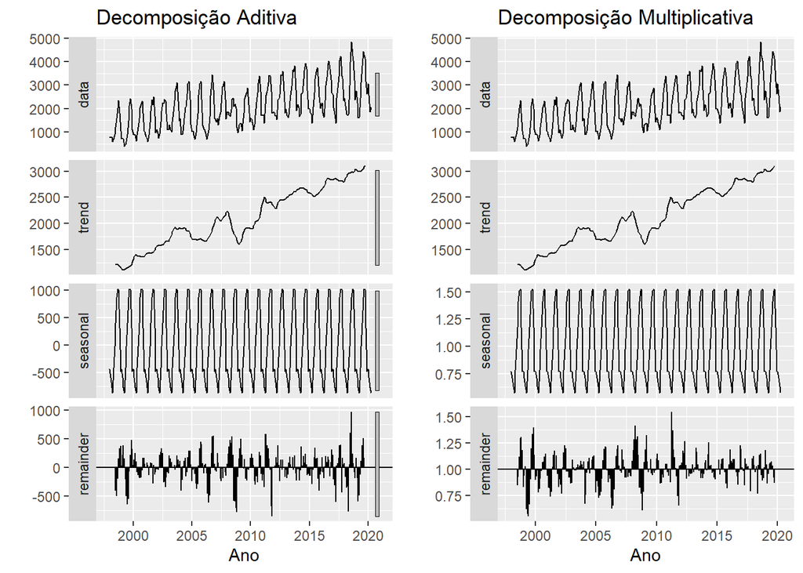

```r
d1 <- ts.fertcons%>%
  decompose(type= "additive")%>%
  autoplot() + xlab("Ano")+
  ggtitle("Decomposição Aditiva")

d2 <- ts.fertcons%>%
  decompose(type= "multiplicative")%>%
  autoplot() + xlab("Ano")+
  ggtitle("Decomposição Multiplicativa")

grid.arrange(d1,d2,ncol = 2)
```

### Sazonalidade

Verifica-se que os meses de agosto, setembro e outubro, são os de maior entrega de fertilizantes e os piores meses parecem ser os de março e abril iniciando um novo ciclo de crescimento em maio o que parece adequado aos períodos de safra e entresafra.

Parece haver um crescimento da entrega, em valores absolutos, em todos os meses ao longo dos anos embora haja vales em alguns anos indicando possíveis crises econômicas como a de 2008.

[figure not shown]

```r
q1 <- ggseasonplot(ts.fertcons, year.labels=TRUE, year.labels.left=TRUE) +
  ylab("$ million") +
  ggtitle("Seasonal plot: antidiabetic drug sales")

q2 <- ggseasonplot(ts.fertcons, polar = TRUE) +
  ylab("$ million") +
  ggtitle("Seasonal plot: antidiabetic drug sales")

q3 <- ggsubseriesplot(ts.fertcons) +
  ylab("T 1000") +
  ggtitle("Seasonal subseries plot: Entrega de Fertilizantes")


grid.arrange(q1,q2, q3, nrow =3)
```

## Autocorrelação

No correlograma da série é possível notar a presença da sazonaliade nos picos múltiplos de 12, como as cavidades tentem a ficar dois quartos atrás dos picos os múltiplos de 6 são os mais negativos. O dacaimento muito lento do ACF pode ser sinal de não estacionariedade. Como o decaimento do PACF é menos lento que o do ACF modelos com compomentes autorregressivos tem a possibilidade de se adequar melhor.

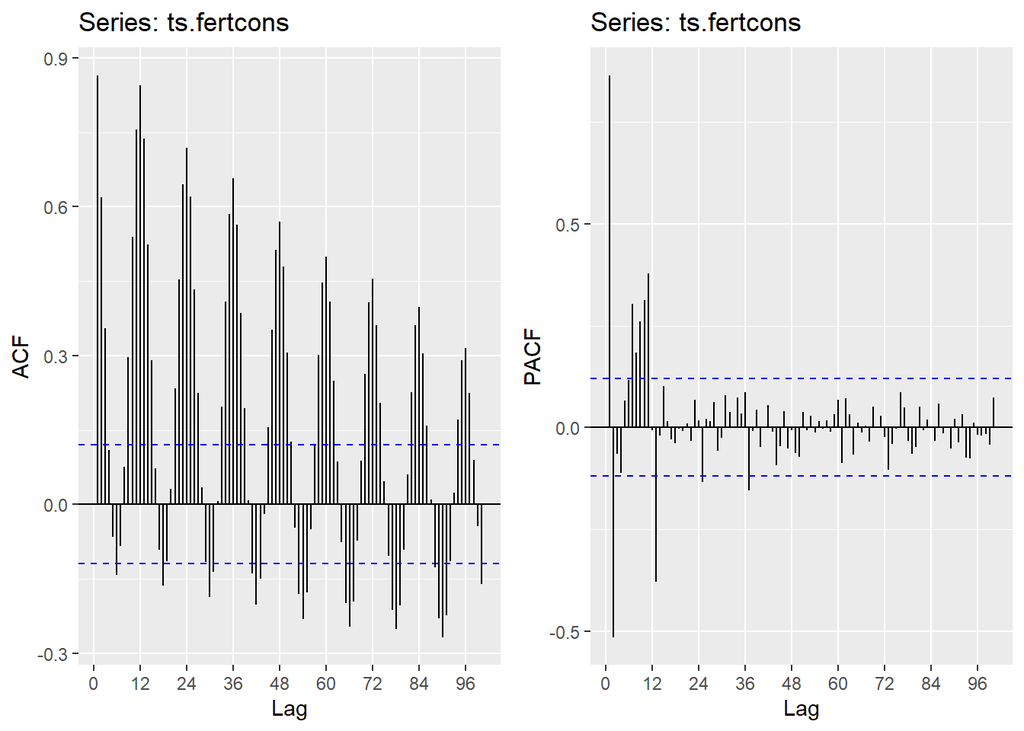

```r
a1 <- ggAcf(ts.fertcons, lag=100)
a2 <- ggPacf(ts.fertcons, lag=100)
grid.arrange(a1,a2,ncol = 2)
```

### Estacionariedade da Série

Nos testes formais temos as seguintes conclusões:

- ADF: H<sub>0</sub> - Série não estacionária -> Rejeitada
- KPPS: H<sub>0</sub> - Série estácionária -> Rejeitada
- PP: H<sub>0</sub> - Série não estacionária -> Rejeitada

A análise gráfica e o teste KPPS indicam que a série não é estacionária, porém os testes ADF e PP indicam que a série é estacionaria.

```r
adf.test(ts.fertcons)
```

```
##
##  Augmented Dickey-Fuller Test
##
## data:  ts.fertcons
## Dickey-Fuller = -10.174, Lag order = 6, p-value = 0.01
## alternative hypothesis: stationary
```

```r
kpss.test(ts.fertcons)
```

```
##
##  KPSS Test for Level Stationarity
##
## data:  ts.fertcons
## KPSS Level = 2.644, Truncation lag parameter = 5, p-value = 0.01
```

```r
pp.test(ts.fertcons)
```

```
##
##  Phillips-Perron Unit Root Test
##
## data:  ts.fertcons
## Dickey-Fuller Z(alpha) = -81.213, Truncation lag parameter = 5, p-value
## = 0.01
## alternative hypothesis: stationary
```

Ao tentar obter convergência nos resultados dos testes através da diferenciação da série observamos que com uma diferenciação é possível manter os resultados do ADF e do PP e inverter o resultado do kpss obtendo indicação de estacionariedade nos 3 testes.

```r
#Utililzando ndiff para saber o número de diferenciações necessárias
ndiffs(ts.fertcons)
```

```
## [1] 1
```

```r
# Diferenciando a série
ts.diff_fertcons <- diff(ts.fertcons)

# Testando

adf.test(ts.diff_fertcons)
```

```
##
##  Augmented Dickey-Fuller Test
##
## data:  ts.diff_fertcons
## Dickey-Fuller = -12.85, Lag order = 6, p-value = 0.01
## alternative hypothesis: stationary
```

```r
kpss.test(ts.diff_fertcons)
```

```
##
##  KPSS Test for Level Stationarity
##
## data:  ts.diff_fertcons
## KPSS Level = 0.011981, Truncation lag parameter = 5, p-value = 0.1
```

```r
pp.test(ts.diff_fertcons)
```

```
##
##  Phillips-Perron Unit Root Test
##
## data:  ts.diff_fertcons
## Dickey-Fuller Z(alpha) = -135.18, Truncation lag parameter = 5, p-value
## = 0.01
## alternative hypothesis: stationary
```

# Modelos de Estudo

Inicialmente vamos montar a base de treino e a base de teste que servirão para todo o exercício.

```r
train <- window(ts.fertcons, start = c(2007,1), end = c(2018,12))
test <-window(ts.fertcons, start = c(2019,1),end = c(2020,4))
```

## Modelos por Exponential Smoothing

Vamos utilizar 3 modelos e tentar comparar a capacidade de forecasting dos mesmos, a saber:

- Holt Winters Aditivo
- Holt Winters Multiplicativo
- ETS

No caso do ETS vamos verificar se ele indica outra possibilidade ou se a indicação bate com HWA ou HWM.

```r
# Aditivo

fit_holt_ad <- hw(train,seasonal = "additive", h=14, level=95)

summary(fit_holt_ad)
```

```
##
## Forecast method: Holt-Winters' additive method
##
## Model Information:
## Holt-Winters' additive method
##
## Call:
##  hw(y = train, h = 14, seasonal = "additive", level = 95)
##
##   Smoothing parameters:
##     alpha = 0.856
##     beta  = 1e-04
##     gamma = 1e-04
##
##   Initial states:
##     l = 2312.1115
##     b = 6.7753
##     s = -534.0436 139.6893 877.0535 1017.621 955.1693 484.0101
##            97.7664 -322.4482 -874.8917 -788.5711 -571.2841 -480.0711
##
##   sigma:  283.4815
##
##      AIC     AICc      BIC
## 2359.071 2363.928 2409.557
##
## Error measures:
##                     ME     RMSE      MAE        MPE     MAPE      MASE
## Training set -2.831316 267.2689 206.2041 -0.7949484 9.330779 0.6332786
##                    ACF1
## Training set 0.02211294
##
## Forecasts:
##          Point Forecast     Lo 95    Hi 95
## Jan 2019       2458.947 1903.3331 3014.560
## Feb 2019       2374.347 1642.9242 3105.769
## Mar 2019       2163.893 1291.3644 3036.421
## Apr 2019       2084.273 1090.4490 3078.097
## May 2019       2643.407 1541.5347 3745.278
## Jun 2019       3070.358 1870.1029 4270.612
## Jul 2019       3463.470 2172.2861 4754.653
## Aug 2019       3941.253 2565.1155 5317.390
## Sep 2019       4010.441 2554.2800 5466.603
## Oct 2019       3876.609 2344.5802 5408.639
## Nov 2019       3145.963 1541.6330 4750.293
## Dec 2019       2478.961  805.4348 4152.488
## Jan 2020       2539.748  799.7401 4279.756
## Feb 2020       2455.148  651.1102 4259.186
```

```r
# Multiplicativo

fit_holt_multi <- hw(train,seasonal = "multiplicative", h=14, level=95)
summary(fit_holt_multi)
```

```
##
## Forecast method: Holt-Winters' multiplicative method
##
## Model Information:
## Holt-Winters' multiplicative method
##
## Call:
##  hw(y = train, h = 14, seasonal = "multiplicative", level = 95)
##
##   Smoothing parameters:
##     alpha = 0.574
##     beta  = 2e-04
##     gamma = 0.2096
##
##   Initial states:
##     l = 2239.6086
##     b = 3.7549
##     s = 0.6186 1.0998 1.432 1.4238 1.3205 1.2327
##            1.0968 0.9359 0.7032 0.7402 0.7347 0.6617
##
##   sigma:  0.1409
##
##      AIC     AICc      BIC
## 2396.305 2401.162 2446.792
##
## Error measures:
##                    ME     RMSE      MAE       MPE     MAPE      MASE      ACF1
## Training set 2.873734 289.6995 218.8679 -1.153256 9.866531 0.6721706 0.1814767
##
## Forecasts:
##          Point Forecast     Lo 95    Hi 95
## Jan 2019       2350.092 1700.9004 2999.283
## Feb 2019       2104.078 1432.4040 2775.752
## Mar 2019       1871.226 1202.7512 2539.700
## Apr 2019       1813.319 1102.9816 2523.656
## May 2019       2604.476 1501.2991 3707.653
## Jun 2019       3371.474 1843.1537 4899.795
## Jul 2019       3906.228 2025.9978 5786.458
## Aug 2019       4413.236 2171.5315 6654.940
## Sep 2019       4293.150 2003.4031 6582.897
## Oct 2019       4027.382 1781.2963 6273.468
## Nov 2019       3314.405 1388.2507 5240.560
## Dec 2019       2403.021  952.1158 3853.927
## Jan 2020       2391.929  851.2651 3932.594
## Feb 2020       2141.494  717.5890 3565.400
```

```r
# Plotando os modelos

h1 <- autoplot(train, serie="Serie Original") +
  autolayer(fit_holt_ad$fitted, serie = "Modelo HW Aditivo") +
  autolayer(fit_holt_ad, serie = "Previsão",showgap = F, PI=F) +
  autolayer(test, series= "Base de Teste")


h2 <- autoplot(train, serie="Serie Original") +
  autolayer(fit_holt_multi$fitted, serie = "Modelo HW Aditivo") +
  autolayer(fit_holt_multi, serie = "Previsão",showgap = F, PI=F) +
  autolayer(test, series= "Base de Teste")



# Utilizando modelo ETS ( Error, Trend, Seasonal)

ets_model <- ets(train)
fit_ets <- forecast(ets_model, h=14)

h3 <- autoplot(train, serie="Serie Original") +
  autolayer(fit_ets$fitted, serie = "Modelo HW Aditivo") +
  autolayer(fit_ets, serie = "Previsão",showgap = F, PI=F) +
  autolayer(test, series= "Base de Teste")

# Resultado do Modelo ETS
summary(ets_model)
```

```
## ETS(A,N,A)
##
## Call:
##  ets(y = train)
##
##   Smoothing parameters:
##     alpha = 0.8702
##     gamma = 1e-04
##
##   Initial states:
##     l = 2145.9902
##     s = -534.9342 137.9396 890.1354 1002.916 900.3112 484.3706
##            96.9238 -325.0633 -865.0764 -790.5557 -568.6864 -428.281
##
##   sigma:  280.5454
##
##      AIC     AICc      BIC
## 2354.305 2358.055 2398.852
##
## Training set error measures:
##                    ME     RMSE      MAE        MPE     MAPE      MASE
## Training set 6.248057 266.5592 203.7757 -0.3261722 9.142053 0.6258205
##                    ACF1
## Training set 0.01554042
```

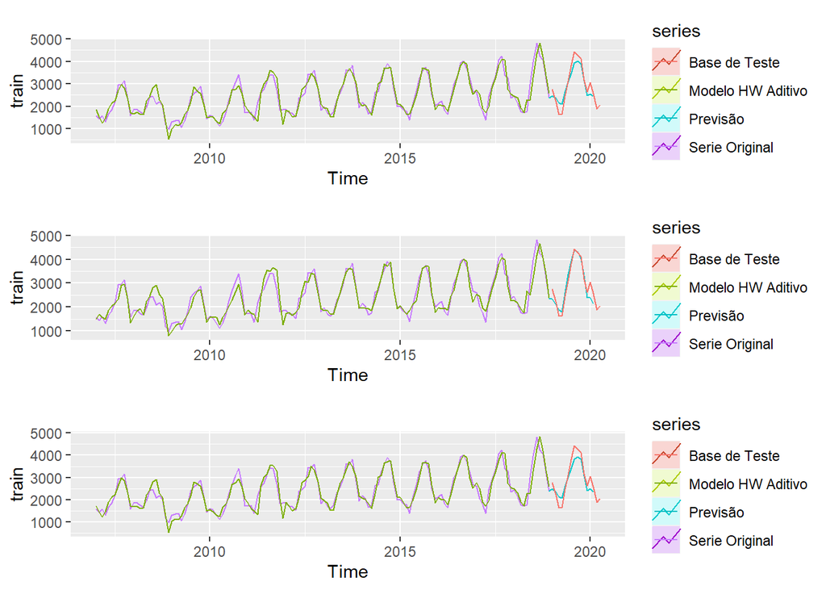

```r
grid.arrange(h1,h2,h3, nrow=3)
```

```r
print("Modelo HW - Aditivo")
```

```
## [1] "Modelo HW - Aditivo"
```

```r
pander(accuracy(fit_holt_ad))
```

|  | ME | RMSE | MAE | MPE | MAPE | MASE | ACF1 |
| --- | --- | --- | --- | --- | --- | --- | --- |
| **Training set** | -2.831 | 267.3 | 206.2 | -0.7949 | 9.331 | 0.6333 | 0.02211 |

```r
print("Modelo HW - Multiplicativo")
```

```
## [1] "Modelo HW - Multiplicativo"
```

```r
pander(accuracy(fit_holt_multi))
```

|  | ME | RMSE | MAE | MPE | MAPE | MASE | ACF1 |
| --- | --- | --- | --- | --- | --- | --- | --- |
| **Training set** | 2.874 | 289.7 | 218.9 | -1.153 | 9.867 | 0.6722 | 0.1815 |

```r
print("Modelo ETS")
```

```
## [1] "Modelo ETS"
```

```r
pander(accuracy(fit_ets))
```

|  | ME | RMSE | MAE | MPE | MAPE | MASE | ACF1 |
| --- | --- | --- | --- | --- | --- | --- | --- |
| **Training set** | 6.248 | 266.6 | 203.8 | -0.3262 | 9.142 | 0.6258 | 0.01554 |

## SARIMA

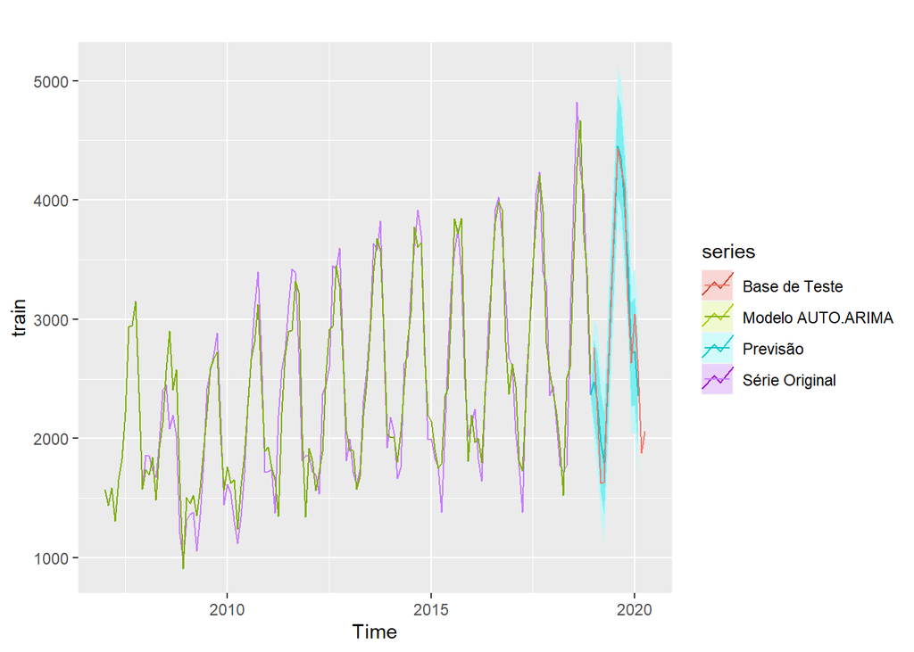

```r
autoarima_model <- auto.arima(train, seasonal = TRUE, stepwise=FALSE, approximation = FALSE)
fit_autoarima_model <- forecast(autoarima_model, h=14)

autoplot(train, series ="Série Original") +
  autolayer(fit_autoarima_model$fitted, series = "Modelo AUTO.ARIMA")+
  autolayer(fit_autoarima_model, series = "Previsão", showgap = FALSE) +
  autolayer(test, series= "Base de Teste")
```

```r
print("Modelo Auto Arima")
```

```
## [1] "Modelo Auto Arima"
```

```r
pander(accuracy(autoarmima_model))
```

[output not shown]

## Análise de Resíduos

Avaliando os resíduos de cada um dos modelos é possível verificar pelos p-values do Ljung-Box test que o modelo aditivo apresenta um p-value um pouco maior que 0,05, o ETS(A,N,A) possui um p-value maior que 0,05. Ambos possuem resíduos independentes e identicamente distribuidos. No caso do HW multiplicativo o p-value é muito pequeno permitindo rejeitar a hipótese nula, isto é, os resíduos do modelo apresentam problemas de correlação entre os resíduos. O modelo sarima possui um p-value maior que 0,05 e que o modelo ETS. Do ponto de vista dos resíduos o modelo autoarima parece ser o mais ajustado.

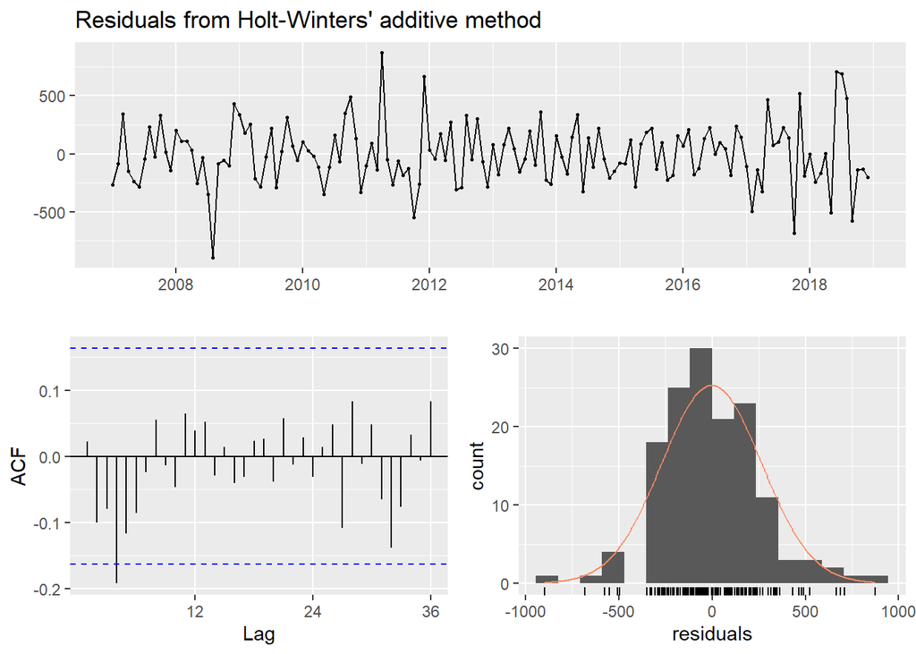

```
##
##  Ljung-Box test
##
## data:  Residuals from Holt-Winters' additive method
## Q* = 15.44, df = 8, p-value = 0.05113
##
## Model df: 16.   Total lags used: 24
```

```r
checkresiduals(fit_holt_ad)
```

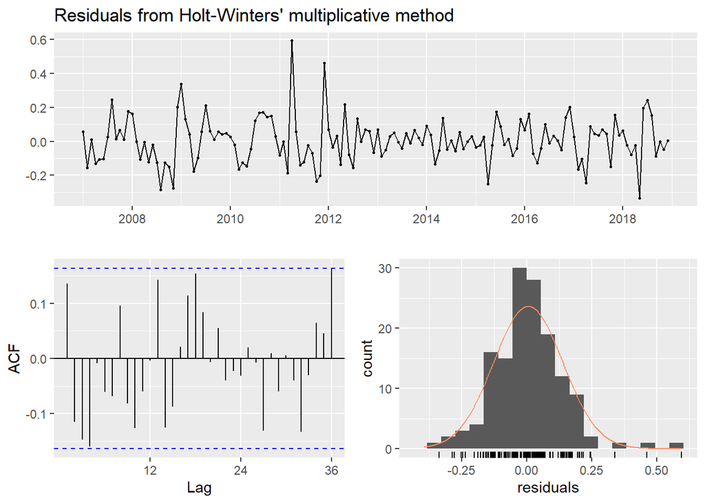

```
##
##  Ljung-Box test
##
## data:  Residuals from Holt-Winters' multiplicative method
## Q* = 33.994, df = 8, p-value = 4.073e-05
##
## Model df: 16.   Total lags used: 24
```

```r
checkresiduals(fit_holt_multi)
```

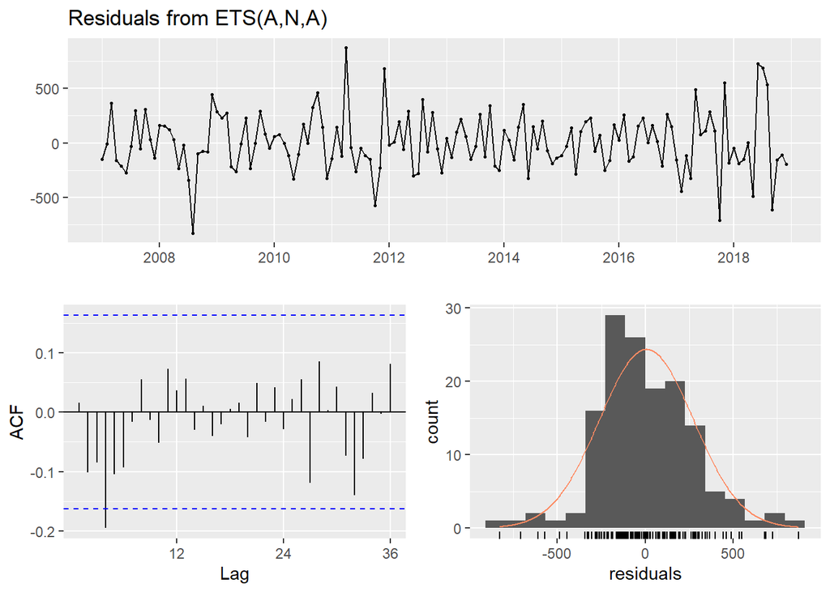

```
##
##  Ljung-Box test
##
## data:  Residuals from ETS(A,N,A)
## Q* = 15.626, df = 10, p-value = 0.1108
##
## Model df: 14.   Total lags used: 24
```

```r
checkresiduals(ets_model)
```

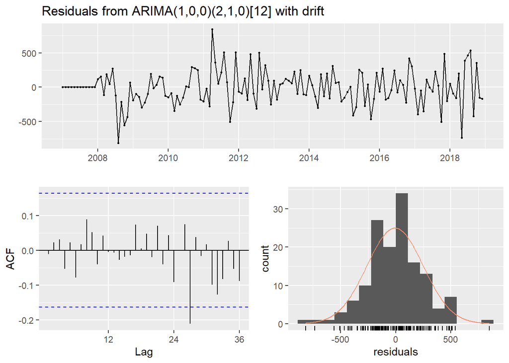

```
##
##  Ljung-Box test
##
## data:  Residuals from ARIMA(1,0,0)(2,1,0)[12] with drift
## Q* = 8.3969, df = 20, p-value = 0.9889
##
## Model df: 4.   Total lags used: 24
```

```r
checkresiduals(autoarima_model)
```